# Class 3 - EDA and Missing Data

June 7, 2020

## Required Libraires

- `tidyverse`: Data Wrangling & Visualisation
- `DataExplorer`, `ggcorrplot` & `psych`: EDA & Descriptive Stats
- `naniar`: To deal with Missing Data

```r
library(pacman)
p_load(DataExplorer, ggcorrplot, naniar, psych, tidyverse)
```

## Tips and Tricks

- `dplyr`: `starts_with()` and `ends_with()`
- Useful for selecting similar columns

```r
iris %>%
  select(starts_with('Sepal')) %>% head()
```

```
##   Sepal.Length Sepal.Width
## 1          5.1         3.5
## 2          4.9         3.0
## 3          4.7         3.2
## 4          4.6         3.1
## 5          5.0         3.6
## 6          5.4         3.9
```

## Tips and Tricks

- `dplyr`: `starts_with()` and `ends_with()`
- Useful for selecting similar columns

```r
iris %>%
  select(ends_with('Width')) %>% head()
```

```
##   Sepal.Width Petal.Width
## 1         3.5         0.2
## 2         3.0         0.2
## 3         3.2         0.2
## 4         3.1         0.2
## 5         3.6         0.2
## 6         3.9         0.4
```

## What is EDA?

- EDA stands for Exploratory Data Analysis
- It is an important part of every data analysis project
  - It is **a means to generate questions about the data**
  - Look for patterns / initial answers by visualising, transforming and modelling the data
  - Use what you learn to refine your questions and generate new questions
- The **Goal of EDA** is to:
  - Develop a clearer understanding of the data
  - What kind of variation occurs within my variables?
  - What type of covariation occurs between my variables?
  - Find Patterns in the Data
  - Deal with Missing Data

## Understanding the data

```r
# Get the shape of the data
dim(diamonds)
```

```
## [1] 53940    10
```

## Understanding the data

```r
# Get the structure of the data
str(diamonds)
```

```
## tibble [53,940 × 10] (S3: tbl_df/tbl/data.frame)
##  $ carat  : num [1:53940] 0.23 0.21 0.23 0.29 0.31 0.24 0.24 0.26 0.22 0.23 ...
##  $ cut    : Ord.factor w/ 5 levels "Fair"<"Good"<..: 5 4 2 4 2 3 3 3 1 3 ...
##  $ color  : Ord.factor w/ 7 levels "D"<"E"<"F"<"G"<..: 2 2 2 6 7 7 6 5 2 5 ...
##  $ clarity: Ord.factor w/ 8 levels "I1"<"SI2"<"SI1"<..: 2 3 5 4 2 6 7 3 4 5 ...
##  $ depth  : num [1:53940] 61.5 59.8 56.9 62.4 63.3 62.8 62.3 61.9 65.1 59.4 ...
##  $ table  : num [1:53940] 55 61 65 58 58 57 57 55 61 61 ...
##  $ price  : int [1:53940] 326 326 327 334 335 336 336 337 337 338 ...
##  $ x      : num [1:53940] 3.95 3.89 4.05 4.2 4.34 3.94 3.95 4.07 3.87 4 ...
##  $ y      : num [1:53940] 3.98 3.84 4.07 4.23 4.35 3.96 3.98 4.11 3.78 4.05 ...
##  $ z      : num [1:53940] 2.43 2.31 2.31 2.63 2.75 2.48 2.47 2.53 2.49 2.39 ...
```

## Understanding the data

```r
summary(diamonds[, 1:7])
```

```
##      carat               cut        color        clarity          depth
##  Min.   :0.2000   Fair     : 1610   D: 6775   SI1    :13065   Min.   :43.00
##  1st Qu.:0.4000   Good     : 4906   E: 9797   VS2    :12258   1st Qu.:61.00
##  Median :0.7000   Very Good:12082   F: 9542   SI2    : 9194   Median :61.80
##  Mean   :0.7979   Premium  :13791   G:11292   VS1    : 8171   Mean   :61.75
##  3rd Qu.:1.0400   Ideal    :21551   H: 8304   VVS2   : 5066   3rd Qu.:62.50
##  Max.   :5.0100                     I: 5422   VVS1   : 3655   Max.   :79.00
##                                     J: 2808   (Other): 2531
##      table           price
##  Min.   :43.00   Min.   :  326
##  1st Qu.:56.00   1st Qu.:  950
##  Median :57.00   Median : 2401
##  Mean   :57.46   Mean   : 3933
##  3rd Qu.:59.00   3rd Qu.: 5324
##  Max.   :95.00   Max.   :18823
##
```

## Variation of Variables

- A **variable** refers to an observation or quality that we are measuring or understanding
  - E.g. the weight of a person, the speed of a car, the eye colour of a person, gender
- **Variation of variables** looks at the tendency of these variables to change from one measurement to another
  - How does the height of each student vary in a given classroom / how does the daily temperature change in a year?
- Every variable has its own pattern of variation, which can provide interesting information
- The best way to understand this pattern is to visualize the distribution of the variable’s values

## Variation of Variables

- To visualize the distribution of the variable’s values, we need to first determine if the variable is discrete (categorical) or continuous
- Discrete variables can only take on a limited set of values, continuous variables can take on an “infinite” set of values
  - **Discrete** <- Gender, Language, Dog breed, Season, etc
  - **Continuous** <- Speed, Height, Age, Income, etc
- Can you think of some other examples?

## How do you determine the type of variable?

```r
# Discrete
unique(diamonds$cut)
```

```
## [1] Ideal     Premium   Good      Very Good Fair
## Levels: Fair < Good < Very Good < Premium < Ideal
```

```r
# Continuous
length(unique(diamonds$carat))
```

```
## [1] 273
```

## Variation of Discrete Variables

- Use `geom_bar()`, with only one aesthetic

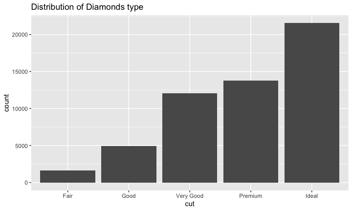

```r
# Tall bars denote the most common values of a variable, vice versa
ggplot(diamonds, aes(x = cut)) + geom_bar() + labs(title = "Distribution of Diamonds type")
```

## Variation of Continuous Variables

- Use `geom_histogram()`, with only one aesthetic

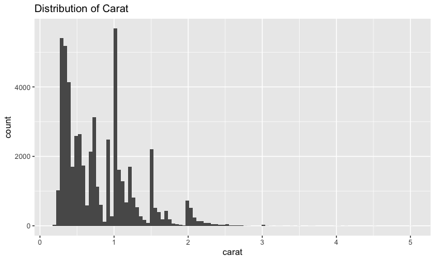

```r
# Areas with missing bars reveal values with very low counts
ggplot(diamonds, aes(x = carat)) + geom_histogram(bins = 100) + labs(title = "Distribution of Carat")
```

## Variation of Continuous Variables

- To overlay multiple histograms use `geom_freqpoly()`

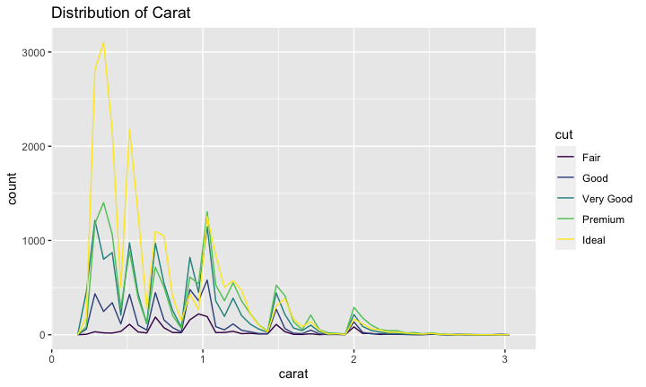

```r
diamonds %>% filter(carat <= 3) %>%
  ggplot(aes(x = carat, colour = cut)) + geom_freqpoly(bins = 50) + labs(title = "Distribution of Carat")
```

## The Lazy Man

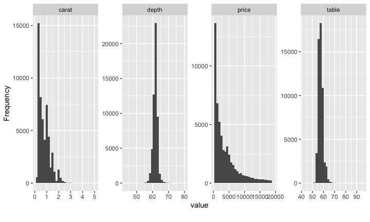

```r
# `plot_histogram()` from the DataExplorer package
plot_histogram(diamonds[, 1:7])
```

## Descriptive Statistics

```r
describe(diamonds[, 1:7])
```

```
##          vars     n    mean      sd median trimmed     mad   min      max
## carat       1 53940    0.80    0.47    0.7    0.73    0.47   0.2     5.01
## cut*        2 53940    3.90    1.12    4.0    4.04    1.48   1.0     5.00
## color*      3 53940    3.59    1.70    4.0    3.55    1.48   1.0     7.00
## clarity*    4 53940    4.05    1.65    4.0    3.91    1.48   1.0     8.00
## depth       5 53940   61.75    1.43   61.8   61.78    1.04  43.0    79.00
## table       6 53940   57.46    2.23   57.0   57.32    1.48  43.0    95.00
## price       7 53940 3932.80 3989.44 2401.0 3158.99 2475.94 326.0 18823.00
##             range  skew kurtosis    se
## carat        4.81  1.12     1.26  0.00
## cut*         4.00 -0.72    -0.40  0.00
## color*       6.00  0.19    -0.87  0.01
## clarity*     7.00  0.55    -0.39  0.01
## depth       36.00 -0.08     5.74  0.01
## table       52.00  0.80     2.80  0.01
## price    18497.00  1.62     2.18 17.18
```

## Descriptive Statistics

- **Skew**: is a measure of symmetry, or more precisely, the lack of symmetry. A distribution, or data set, is symmetric if it looks the same to the left and right of the center point
- If the skewness is between -0.5 and 0.5, the data are fairly symmetrical
- If the skewness is between -1 and -0.5 (negatively skewed) or between 0.5 and 1 (positively skewed), the data are moderately skewed
- If the skewness is less than -1(negatively skewed) or greater than 1(positively skewed), the data are highly skewed

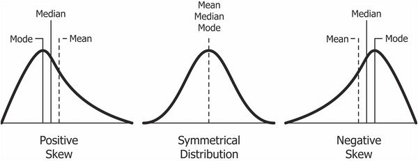

## Descriptive Statistics

- **Kurtosis**: is a measure of whether the data are heavy-tailed or light-tailed relative to a normal distribution
- Data sets with high kurtosis tend to have heavy tails, or outliers
- Data sets with low kurtosis tend to have light tails, or lack of outliers

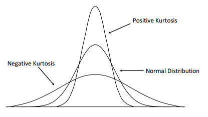

## What are you looking for?

- Which values are the most common? Why?
- Which values are rare? Why?
- Does that match your expectations?
- Do you notice unusual patterns?
- What might explain them?

## Covariation

- Covariation describes the **behaviour between variables**
- Refers to the tendency for the values of 2 or more variables to change in a way that relates to each other
  - E.g. `height` and `weight` tends to exhibit covariation since the taller you are the heavier you are
  - Another example is `Age` and `Income` where you tend to make more money the older you get

## Visualising covariation with a boxplot

- Covariation between **discrete** & **continuous** variable

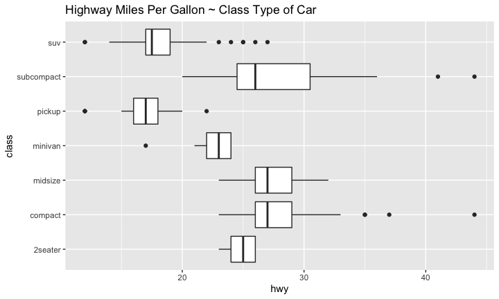

```r
ggplot(mpg, aes(x = class, y = hwy)) + geom_boxplot() +
  labs(title = "Highway Miles Per Gallon ~ Class Type of Car") +
  coord_flip()
```

## Visualising covariation for 2 discrete variables

- For **2 discrete variables**, look at the count of the variables

```r
table(diamonds$color)
```

```
##
##     D     E     F     G     H     I     J
##  6775  9797  9542 11292  8304  5422  2808
```

```r
table(diamonds$cut)
```

```
##
##      Fair      Good Very Good   Premium     Ideal
##      1610      4906     12082     13791     21551
```

## Visualising covariation for 2 discrete variables

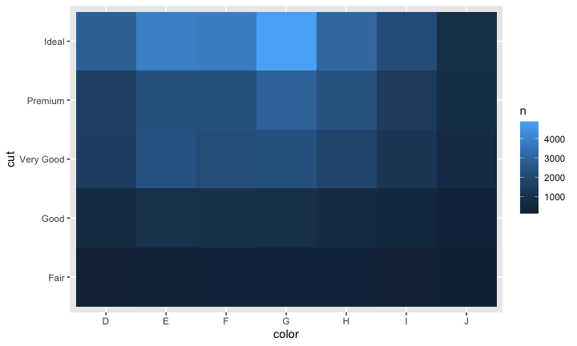

```r
diamonds %>%
  count(color, cut) %>%
  ggplot(aes(x = color, y = cut)) + geom_tile(aes(fill = n))
```

## Visualising covariation for 2 continuous variables

- For **2 continuous variables**, use a scatter plot

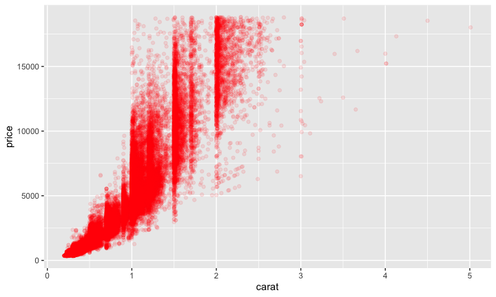

```r
ggplot(diamonds, aes(carat, price)) + geom_point(alpha = 0.1, colour = "red")
```

## Covariation between 2 continuous variables

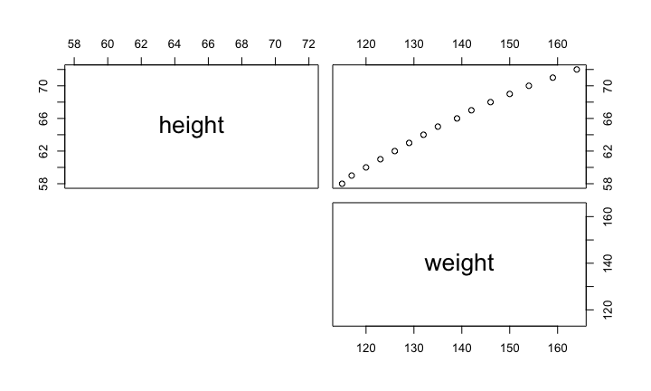

```r
# Using the `pairs()` function
pairs(women, lower.panel=NULL)
```

## Covariation between 2 continuous variables

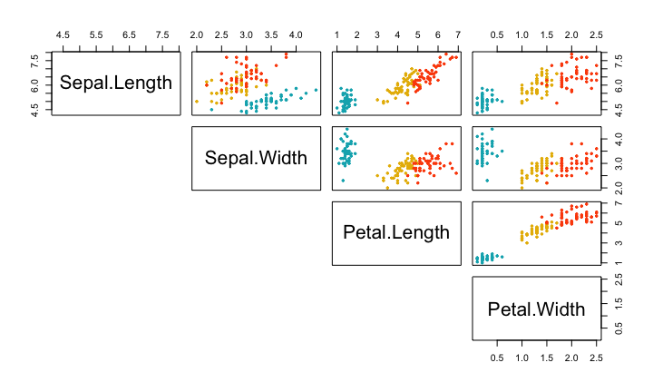

```r
my_cols <- c("#00AFBB", "#E7B800", "#FC4E07")
pairs(iris[,1:4], pch = 19,  cex = 0.5,
      col = my_cols[iris$Species], lower.panel=NULL)
```

## Covariation between 2 continuous variables

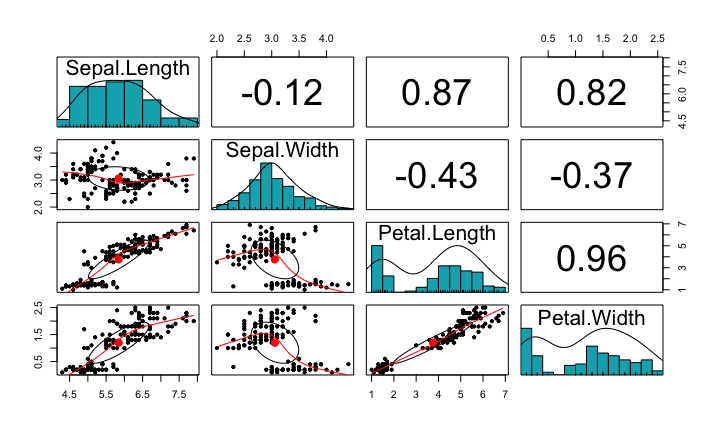

```r
pairs.panels(iris[,-5], method = "pearson", # correlation method
             hist.col = "#00AFBB", density = TRUE,  # show density plots
             ellipses = TRUE) # show correlation ellipses
```

## Covariation between variables

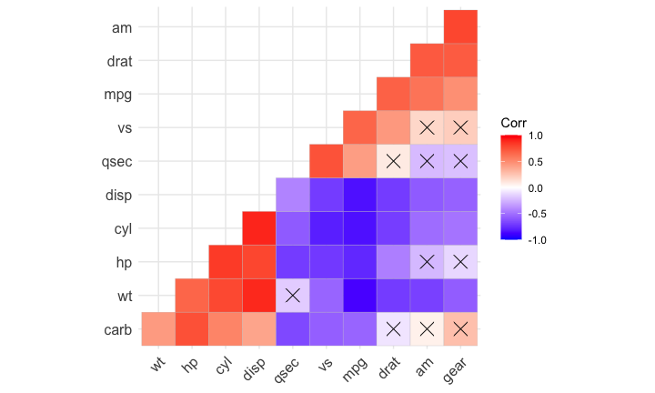

```r
# Using `ggcorrplot` package
ggcorrplot(cor(mtcars), p.mat = cor_pmat(mtcars), hc.order=TRUE, type='lower')
```

## Detecting Patterns

- Patterns in the data provide clues about possible relationships
- If a systemic relationship exists between 2 variables, it would appear as a pattern in the data
  - Is this pattern due to coincidence?
  - Can you describe the relationship implied by the pattern?
  - How strong is the relationship implied by the pattern?
  - What other variables might affect this relationship?
  - Does the relationship change if you look at individual subgroups of the data?

## Detecting Patterns

- A dataset on the eruption of 2 geysers in Yellowstone National Park

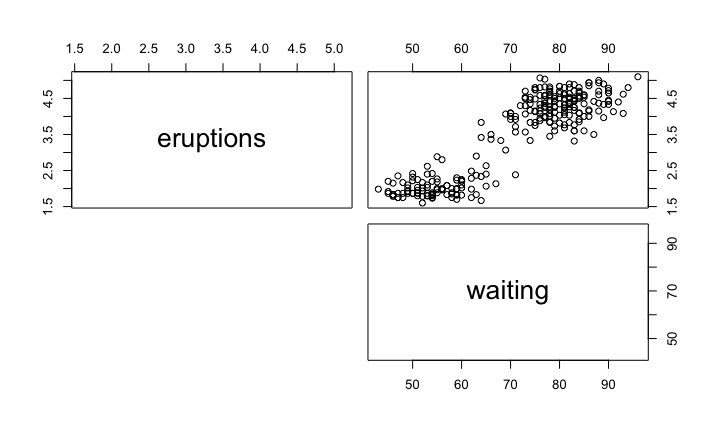

```r
pairs(faithful, lower.panel=NULL)
```

## Detecting Patterns

- A dataset on the arrests per 100,000 residents in America

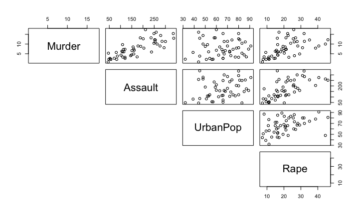

```r
pairs(USArrests, lower.panel=NULL)
```

## Dealing with Missing Data

- Datasets are not **clean** all the time
- Most of the times, you encounter missing data, `is.na()`
- You can deal with missing data in different ways
  - **Interpolate**, **Impute** the data or **Remove** them
- One package that can help you explore missing data is the `naniar` package
  - Visualize your missing data

## Dealing with Missing Data

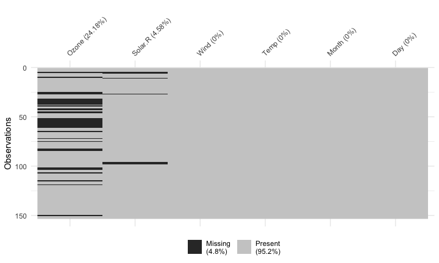

```r
# Use `vis_miss` to visualize missing data
vis_miss(airquality)
```

## Dealing with Missing Data

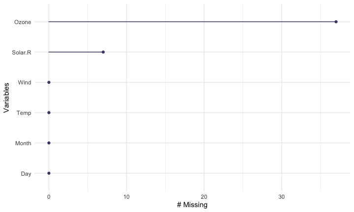

```r
# Use `gg_vis_miss` to visualize missing data
gg_miss_var(airquality)
```

## Exploring Missing Mechanisms

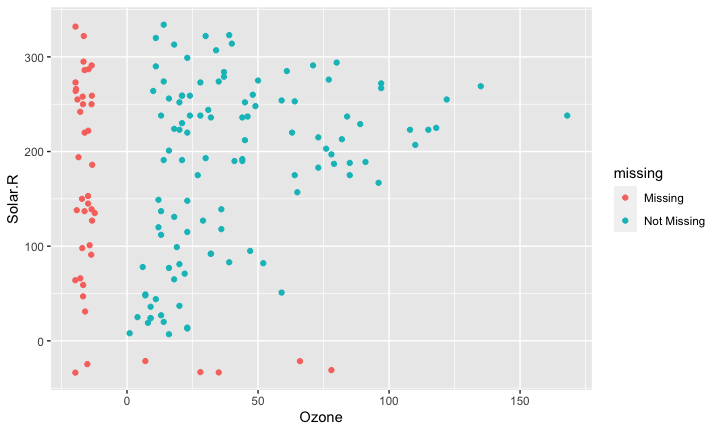

```r
# Use `geom_miss_point()`
ggplot(airquality, aes(x = Ozone, y = Solar.R)) + geom_miss_point()
```

## Recoding Missing Values

- Impute the missing values with the average

```r
x <- c(1:4, NA, 6:7, NA)
print(x)
```

```
## [1]  1  2  3  4 NA  6  7 NA
```

```r
# Recode missing values with the man
x[is.na(x)] <- round(mean(x, na.rm = TRUE))
print(x)
```

```
## [1] 1 2 3 4 4 6 7 4
```

## Use `na.omit()` to remove all rows with missing values

```r
x <- c(1:4, NA, 6:7, NA)
print(x)
```

```
## [1]  1  2  3  4 NA  6  7 NA
```

```r
na.omit(x)
```

```
## [1] 1 2 3 4 6 7
## attr(,"na.action")
## [1] 5 8
## attr(,"class")
## [1] "omit"
```